# Submodels and final models

# 2. Scale analysis:

Another nice way to visualize our results for the scale analysis is to plot the model weight for the global sub-models at each scale.

## 2.1. Natural sub-model:

```r
natural_scale <- purrr::map(unique(data$buffer_dist), ~{

  # Subset the data based on the current buffer distance
  data_subset <- data_scaled %>%

    filter(buffer_dist == .x)

  # Fit the initial model for the current buffer distance
  glmmTMB(squirrel ~

                        lc_coniferous +
                        lc_mixedwood +
                        lc_broadleaf +
                        #lc_shrubs +
                        #lc_herbs +
                        fire_0_15 +

                        (1|array/site),

                      data = data_subset,
                      family = nbinom2,
                      na.action = na.fail)
  }
  ) %>%

  set_names(unique(data$buffer_dist)) %>%

  # Model selection and AIC for each scale
  MuMIn::model.sel(natural_scale) %>%

  as.data.frame(.) %>%

  dplyr::mutate(buffer = as.numeric(rownames(.)),
                submodel = "NATURAL")
```

## 2.2. Anthro composition submodel:

```r
comp_scale <- purrr::map(unique(data$buffer_dist), ~{

  # Subset the data based on the current buffer distance
  data_subset <- data_scaled %>%

    filter(buffer_dist == .x)

  # Fit the initial model for the current buffer distance
  glmmTMB(squirrel ~

                        pipe_trans +
                        seismic +
                        wells_inactive +
                        #harvest_total +
                        wells_active +
                        osm_industrial +
                        harvest_0_15 +
                        #roads +

                        (1|array/site),

                      data = data_subset,
                      family = nbinom2,
                      na.action = na.fail)

  }
  ) %>%

  set_names(unique(data$buffer_dist)) %>%

  # Model selection and AIC for each scale
  MuMIn::model.sel(comp_scale) %>%

  as.data.frame(.) %>%

  dplyr::mutate(buffer = as.numeric(rownames(.)),
                submodel = "COMP")
```

## 2.3. Configuration sub-model:

```r
config_scale <- purrr::map(unique(data$buffer_dist), ~{

  # Subset the data based on the current buffer distance
  data_subset <- data_scaled %>%

    filter(buffer_dist == .x)

  # Fit the initial model for the current buffer distance
  glmmTMB(squirrel ~

                        # configuration variables
                        landscape_shei +
                        nonanthro_ed +
                        landscape_mesh +

                        (1|array/site),

                      data = data_subset,
                      family = nbinom2,
                      na.action = na.fail)

  }
  ) %>%

  set_names(unique(data$buffer_dist)) %>%

  # Model selection and AIC for each scale
  MuMIn::model.sel(config_scale) %>%

  as.data.frame(.) %>%

  dplyr::mutate(buffer = as.numeric(rownames(.)),
                submodel = "CONFIG")
```

## 2.4. Let’s put it all together into a plot:

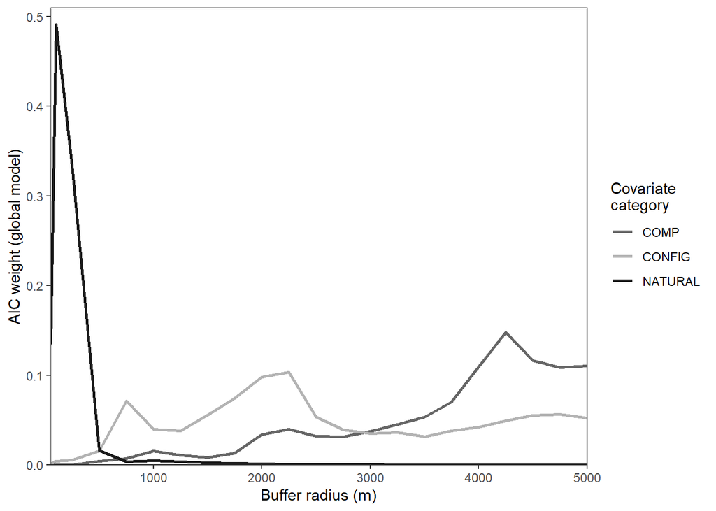

```r
# One big data frame
fig_scale <- bind_rows(natural_scale,
                       comp_scale,
                       config_scale) %>%

  # Plot the model weights as a line.
  ggplot(., aes(x = buffer, y = weight, color = submodel)) +

    geom_line(size = 1) +

    # Old color scheme I didn't like (overwritten)
    scale_color_manual(values =c("#D24D57",
                                 "#1976D2",
                                 "#388E3C")) +

    scale_color_manual(values =c("grey40","grey70","grey10")) +
    #scale_color_viridis_d() +

    theme_bw() +

    # Crop the axis since model weights are low
    scale_y_continuous(limits = c(0, 0.51), expand = expansion(add = c(0, 0))) +

    scale_x_continuous(expand = c(0,0)) +

    labs(x = "Buffer radius (m)",
         y = "AIC weight (global model)",
         color = "Covariate \ncategory") +

    # Remove all grid lines
    theme(panel.grid = element_blank()) +

    # Squirrel icon for funsies. Wrong spp. but whatever.
    add_phylopic(
      uuid = get_uuid(name = "Sciurus vulgaris"),
      x = 4400,
      y = 0.88,
      height = 0.24
      )
fig_scale
```

```r
ggsave("./figures/redsquirrel_neg_binomial_submodel_scale_modelweight.png", width = 7, height = 4, dpi = 500)
```

## 2.5. Identify top scales:

```r
# Pull from the model or specify manually. Manual means we don't need to re-run this every time.
natural_scale$buffer[1]
```

```
## [1] 100
```

```r
nat_buffer <- 100

comp_scale$buffer[1]
```

```
## [1] 4250
```

```r
comp_buffer <- 4250

config_scale$buffer[1]
```

```
## [1] 2250
```

```r
config_buffer <- 2250
```

# 3. Construct the final dataset (best spatial scales)

We will pull out the predictors from the submodels **at the appropriate spatial scales** and merge this into one big dataset for final models. This selects a couple extra columns that we don’t actually want to model but that’s fine, this was efficient *#sueme*

```r
data_final_scaled <- bind_cols(

  # response variables
  data_scaled %>%
    select(1:squirrel) %>%
    distinct(),

  # natural data scaled by natural buffer
  data_scaled %>%
    filter(buffer_dist == nat_buffer) %>%
    select(fire_0_15:lc_wetland_treed) %>%
    mutate(natural_buffer = nat_buffer), # won't use this column, just keeping track of the scale somehow

  # composition data scaled by composition buffer
  data_scaled %>%
    filter(buffer_dist == comp_buffer) %>%
    select(harvest_0_15:wells_total) %>%
    mutate(comp_buffer = comp_buffer), # won't use this column, just keeping track of the scale somehow

  # configuration data
  data_scaled %>%
    filter(buffer_dist == config_buffer) %>%
    select(contains("nonanthro") | contains("landscape") | contains("cfi")) %>%
    mutate(config_buffer = config_buffer) # won't use this column, just keeping track of the scale somehow
  ) %>%

  relocate(contains("buffer"), .after=("squirrel"))

summary(data_final_scaled)
```

```
##     array               site               month             year
##  Length:4918        Length:4918        Min.   : 1.000   Min.   :2021
##  Class :character   Class :character   1st Qu.: 4.000   1st Qu.:2022
##  Mode  :character   Mode  :character   Median : 7.000   Median :2023
##                                        Mean   : 6.634   Mean   :2023
##                                        3rd Qu.:10.000   3rd Qu.:2024
##                                        Max.   :12.000   Max.   :2024
##
##     squirrel       natural_buffer  comp_buffer   config_buffer
##  Min.   : 0.0000   Min.   :100    Min.   :4250   Min.   :2250
##  1st Qu.: 0.0000   1st Qu.:100    1st Qu.:4250   1st Qu.:2250
##  Median : 0.0000   Median :100    Median :4250   Median :2250
##  Mean   : 0.9339   Mean   :100    Mean   :4250   Mean   :2250
##  3rd Qu.: 1.0000   3rd Qu.:100    3rd Qu.:4250   3rd Qu.:2250
##  Max.   :70.0000   Max.   :100    Max.   :4250   Max.   :2250
##
##    fire_0_15         fire_gt_15      pct_lari_lar      lc_broadleaf
##  Min.   :-0.2844   Min.   :-0.190   Min.   :-0.3749   Min.   :-0.6332
##  1st Qu.:-0.2844   1st Qu.:-0.190   1st Qu.:-0.3749   1st Qu.:-0.6284
##  Median :-0.2844   Median :-0.190   Median :-0.3749   Median :-0.5125
##  Mean   : 0.0000   Mean   : 0.000   Mean   : 0.0000   Mean   : 0.0000
##  3rd Qu.:-0.2844   3rd Qu.:-0.190   3rd Qu.:-0.3232   3rd Qu.: 0.1606
##  Max.   : 4.5335   Max.   : 7.409   Max.   : 8.3161   Max.   : 3.1892
##
##  lc_coniferous        lc_herbs         lc_mixedwood       lc_shrubs
##  Min.   :-1.3520   Min.   :-0.52107   Min.   :-0.6342   Min.   :-0.2440
##  1st Qu.:-0.9249   1st Qu.:-0.52107   1st Qu.:-0.6203   1st Qu.:-0.2440
##  Median :-0.1031   Median :-0.44105   Median :-0.4386   Median :-0.2440
##  Mean   : 0.0000   Mean   : 0.00000   Mean   : 0.0000   Mean   : 0.0000
##  3rd Qu.: 0.8063   3rd Qu.: 0.03641   3rd Qu.: 0.1295   3rd Qu.:-0.2374
##  Max.   : 2.2948   Max.   : 6.73769   Max.   : 5.1466   Max.   : 8.9180
##
##     lc_water         lc_wetland       lc_wetland_treed   harvest_0_15
##  Min.   :-0.1678   Min.   :-0.56217   Min.   :-1.0134   Min.   :-0.4207
##  1st Qu.:-0.1678   1st Qu.:-0.54608   1st Qu.:-0.8433   1st Qu.:-0.4207
##  Median :-0.1678   Median :-0.44292   Median :-0.3634   Median :-0.4207
##  Mean   : 0.0000   Mean   : 0.00000   Mean   : 0.0000   Mean   : 0.0000
##  3rd Qu.:-0.1678   3rd Qu.: 0.02224   3rd Qu.: 0.6197   3rd Qu.:-0.1659
##  Max.   :12.6617   Max.   : 5.23963   Max.   : 3.0220   Max.   : 4.9011
##
```

[output cut: 49 more lines]

```
##  Min.   :-0.79501   Min.   :-3.52743   Min.   :-3.9765   Min.   :-0.9601
##  1st Qu.:-0.51403   1st Qu.:-0.60965   1st Qu.:-0.5383   1st Qu.:-0.6491
##  Median :-0.29480   Median : 0.08809   Median : 0.2545   Median :-0.3108
##  Mean   : 0.00000   Mean   : 0.00000   Mean   : 0.0000   Mean   : 0.0000
##  3rd Qu.: 0.06182   3rd Qu.: 0.67378   3rd Qu.: 0.7550   3rd Qu.: 0.2936
##  Max.   : 5.73543   Max.   : 2.64626   Max.   : 1.7992   Max.   : 5.9740
##
##  cfi_site_with_harvest cfi_site_with_vegedges
##  Min.   :-1.0134       Min.   :-1.0053
##  1st Qu.:-0.6678       1st Qu.:-0.6476
##  Median :-0.2978       Median :-0.3164
##  Mean   : 0.0000       Mean   : 0.0000
##  3rd Qu.: 0.3319       3rd Qu.: 0.3033
##  Max.   : 5.5758       Max.   : 5.3407
##
```

# 4. Fit models using the best-fit scales for each ‘category’ of variables.

nbinom2 allows the variance to increase with the square of the mean, which seemed to be the best fit to our data (vs nbinom1) in an initial exploration of AIC scores (huge drop in AICc)

```r
m_null <- glmmTMB(squirrel ~ # Squirrel as response variable

                        #lc_coniferous +
                        #lc_mixedwood +
                        #lc_broadleaf +
                        #lc_shrubs +
                        #lc_herbs +
                        #fire_0_15 +

                        (1|array/site), # Nested random effects for every model

                      data = data_final_scaled, # Scaled data as the data
                      family = nbinom2,  # nbinom2 specification
                      na.action = na.fail) # fail the model if there are NAs. Probably a data error.

# Not gonna annotate every model since it should be obvious by now.
m_fire <- glmmTMB(squirrel ~

                        #lc_coniferous +
                        #lc_mixedwood +
                        #lc_broadleaf +
                        #lc_shrubs +
                        #lc_herbs +
                        fire_0_15 +

                        (1|array/site),

                      data = data_final_scaled,
                      family = nbinom2,
                      na.action = na.fail)


m_forest <- glmmTMB(squirrel ~

                        lc_coniferous +
                        lc_mixedwood +
                        lc_broadleaf +
                        #lc_shrubs +
                        #lc_herbs +
                        #fire_0_15 +

                        (1|array/site),

                      data = data_final_scaled,
                      family = nbinom2,
                      na.action = na.fail)

m_forest_fire <- glmmTMB(squirrel ~

                        lc_coniferous +
                        lc_mixedwood +
                        lc_broadleaf +
                        #lc_shrubs +
                        #lc_herbs +
                        fire_0_15 +

                        (1|array/site),

                      data = data_final_scaled,
                      family = nbinom2,
                      na.action = na.fail)


m_landcover <- glmmTMB(squirrel ~

                        lc_coniferous +
                        lc_mixedwood +
                        lc_broadleaf +
                        lc_shrubs +
                        lc_wetland +
                        lc_wetland_treed +
                        #fire_0_15 +

                        (1|array/site),

                      data = data_final_scaled,
                      family = nbinom2,
                      na.action = na.fail)

m_landcover_fire <- glmmTMB(squirrel ~

                        lc_coniferous +
                        lc_mixedwood +
                        lc_broadleaf +
                        lc_shrubs +
                        lc_wetland +
                        lc_wetland_treed +
                        fire_0_15 +

                        (1|array/site),

                      data = data_final_scaled,
                      family = nbinom2,
                      na.action = na.fail)

  m_seis_wells <- glmmTMB(squirrel ~
                        lc_coniferous +
                        lc_mixedwood +
                        lc_broadleaf +
                        fire_0_15 +

                        pipe_trans +
                        seismic +
                        wells_inactive +
                        #harvest_total +
                        #wells_active +
                        #osm_industrial +
                        #harvest_0_15 +
                        #roads +

                        (1|array/site),

                      data = data_final_scaled,
                      family = nbinom2,
                      na.action = na.fail)

  m_harvest <- glmmTMB(squirrel ~
                        lc_coniferous +
                        lc_mixedwood +
                        lc_broadleaf +
                        fire_0_15 +

                        #pipe_trans +
                        #seismic +
                        #wells_inactive +
                        #harvest_total +
                        #wells_active +
                        #osm_industrial +
                        harvest_0_15 +
                        #roads + +

                        (1|array/site),

                      data = data_final_scaled,
                      family = nbinom2,
                      na.action = na.fail)

  m_harvest_seis <- glmmTMB(squirrel ~
                        lc_coniferous +
                        lc_mixedwood +
                        lc_broadleaf +
                        fire_0_15 +

                        pipe_trans +
                        seismic +
                        wells_inactive +
                        #harvest_total +
                        #wells_active +
                        #osm_industrial +
                        harvest_0_15 +
                        #roads +

                        (1|array/site),

                      data = data_final_scaled,
                      family = nbinom2,
                      na.action = na.fail)


  m_active <- glmmTMB(squirrel ~
                        lc_coniferous +
                        lc_mixedwood +
                        lc_broadleaf +
                        fire_0_15 +

                        #pipe_trans +
                        #seismic +
                        #wells_inactive +
                        #harvest_total +
                        wells_active +
                        osm_industrial +
                        #harvest_0_15 +
                        #roads +

                        (1|array/site),

                      data = data_final_scaled,
                      family = nbinom2,
                      na.action = na.fail)

  m_active_harvest <- glmmTMB(squirrel ~
                        lc_coniferous +
                        lc_mixedwood +
                        lc_broadleaf +
                        fire_0_15 +

                        #pipe_trans +
                        #seismic +
                        #wells_inactive +
                        #harvest_total +
                        wells_active +
                        osm_industrial +
                        harvest_0_15 +
                        #roads +
```

```r
                        (1|array/site),

                      data = data_final_scaled,
                      family = nbinom2,
                      na.action = na.fail)

  m_active_seis <- glmmTMB(squirrel ~
                        lc_coniferous +
                        lc_mixedwood +
                        lc_broadleaf +
                        fire_0_15 +

                        pipe_trans +
                        seismic +
                        wells_inactive +
                        #harvest_total +
                        wells_active +
                        osm_industrial +
                        #harvest_0_15 +
                        #roads +

                      (1|array/site),
                      data = data_final_scaled,
                      family = nbinom2,
                      na.action = na.fail)

  m_active_seis_harvest <- glmmTMB(squirrel ~
                        lc_coniferous +
                        lc_mixedwood +
                        lc_broadleaf +
                        fire_0_15 +

                        pipe_trans +
                        seismic +
                        wells_inactive +
                        #harvest_total +
                        wells_active +
                        osm_industrial +
                        harvest_0_15 +
                        #roads +

                        (1|array/site),

                      data = data_final_scaled,
                      family = nbinom2,
                      na.action = na.fail)

    m_het <- glmmTMB(squirrel ~

                        # natural covariates
                        fire_0_15 +
                        lc_broadleaf +
                        lc_coniferous +
                        lc_mixedwood +

                        # configuration variables
                        landscape_shei +
                        #nonanthro_ed +
                        #landscape_mesh +

                        (1|array/site),

                      data = data_final_scaled,
                      family = nbinom2,
                      na.action = na.fail)

  m_edge <- glmmTMB(squirrel ~

                        # natural covariates
                        fire_0_15 +
                        lc_broadleaf +
                        lc_coniferous +
                        lc_mixedwood +

                        # configuration variables
                        #landscape_shei +
                        nonanthro_ed +
                        #landscape_mesh +

                        (1|array/site),

                      data = data_final_scaled,
                      family = nbinom2,
                      na.action = na.fail)


    m_cohesion <- glmmTMB(squirrel ~

                        # natural covariates
                        fire_0_15 +
                        lc_broadleaf +
                        lc_coniferous +
                        lc_mixedwood +

                        # configuration variables
                        nonanthro_cohesion +
                        #landscape_mesh +

                        (1|array/site),

                      data = data_final_scaled,
                      family = nbinom2,
                      na.action = na.fail)

  m_cohesion_mesh <- glmmTMB(squirrel ~

                        # natural covariates
                        fire_0_15 +
                        lc_broadleaf +
                        lc_coniferous +
                        lc_mixedwood +

                        # configuration variables
                        nonanthro_cohesion +
                        landscape_mesh +

                        (1|array/site),

                      data = data_final_scaled,
                      family = nbinom2,
                      na.action = na.fail)

  m_cohesion_shei <- glmmTMB(squirrel ~

                        # natural covariates
                        fire_0_15 +
                        lc_broadleaf +
                        lc_coniferous +
                        lc_mixedwood +

                        # configuration variables
                        nonanthro_cohesion +
                        #landscape_mesh +
                        landscape_shei +

                        (1|array/site),

                      data = data_final_scaled,
                      family = nbinom2,
                      na.action = na.fail)


  m_conn <- glmmTMB(squirrel ~

                        # natural covariates
                        fire_0_15 +
                        lc_broadleaf +
                        lc_coniferous +
                        lc_mixedwood +

                        # configuration variables
                        #landscape_shei +
                        #nonanthro_ed +
                        landscape_mesh +

                        (1|array/site),

                      data = data_final_scaled,
                      family = nbinom2,
                      na.action = na.fail)

  m_edge_conn <- glmmTMB(squirrel ~

                        # natural covariates
                        fire_0_15 +
                        lc_broadleaf +
                        lc_coniferous +
                        lc_mixedwood +

                        # configuration variables
                        #landscape_shei +
                        nonanthro_ed +
                        landscape_mesh +

                        (1|array/site),

                      data = data_final_scaled,
                      family = nbinom2,
                      na.action = na.fail)

  m_het_conn <- glmmTMB(squirrel ~

                        # natural covariates
                        fire_0_15 +
                        lc_broadleaf +
                        lc_coniferous +
                        lc_mixedwood +

                        # configuration variables
                        landscape_shei +
                        #nonanthro_ed +
                        landscape_mesh +

                        (1|array/site),

                      data = data_final_scaled,
                      family = nbinom2,
                      na.action = na.fail)
```

```r
  m_het_edge <- glmmTMB(squirrel ~

                        # natural covariates
                        fire_0_15 +
                        lc_broadleaf +
                        lc_coniferous +
                        lc_mixedwood +

                        # configuration variables
                        landscape_shei +
                        nonanthro_ed +
                        #landscape_mesh +

                        (1|array/site),

                      data = data_final_scaled,
                      family = nbinom2,
                      na.action = na.fail)

  m_config <- glmmTMB(squirrel ~

                        # natural covariates
                        fire_0_15 +
                        lc_broadleaf +
                        lc_coniferous +
                        lc_mixedwood +

                        # configuration variables
                        landscape_shei +
                        nonanthro_ed +
                        landscape_mesh +

                        (1|array/site),

                      data = data_final_scaled,
                      family = nbinom2,
                      na.action = na.fail)

  m_edge_cfi <- glmmTMB(squirrel ~

                        # natural covariates
                        fire_0_15 +
                        lc_broadleaf +
                        lc_coniferous +
                        lc_mixedwood +

                        # configuration variables
                        #landscape_shei +
                        nonanthro_ed +
                        cfi_site +
                        #landscape_mesh +

                        (1|array/site),

                      data = data_final_scaled,
                      family = nbinom2,
                      na.action = na.fail)

  m_edgeXcfi <- glmmTMB(squirrel ~

                        # natural covariates
                        fire_0_15 +
                        lc_broadleaf +
                        lc_coniferous +
                        lc_mixedwood +

                        # configuration variables
                        #landscape_shei +
                        nonanthro_ed +
                        cfi_site +
                        nonanthro_ed*cfi_site +
                        #landscape_mesh +

                        (1|array/site),

                      data = data_final_scaled,
                      family = nbinom2,
                      na.action = na.fail)
```

# 5. Perform model selection

Let’s gather all the models into a list and perform model selection:

```r
#rm(m_nat_comp_config2)

# Pull all models from the global environment
models <- mget(ls(pattern = "m_"))

# PErform model selection on them
models_rank <- MuMIn::model.sel(models) %>%

    as.data.frame(.) %>%

    select(-`disp((Int))`) %>%

    # Tidy up the disgusting glmmTMB names (thanks ChatGPT!!)
    rename_with(~ gsub("cond\\(|disp\\(|\\)|\\(", "", .)) %>%

    rename(intercept = `Int`) %>%

    mutate(model = rownames(.)) %>%

    # Model at the first row
    relocate(model)

models_rank
```

```
##                                       model intercept  fire_0_15 lc_broadleaf
## m_edgeXcfi                       m_edgeXcfi -1.427925 0.15769889   -0.5184199
## m_seis_wells                   m_seis_wells -1.572581 0.11240507   -0.4778583
## m_harvest_seis               m_harvest_seis -1.570776 0.09684067   -0.4733282
## m_edge_cfi                       m_edge_cfi -1.567200 0.16163124   -0.4928295
## m_edge_conn                     m_edge_conn -1.562466 0.19104506   -0.5133915
## m_active_seis                 m_active_seis -1.572573 0.13022726   -0.4723316
## m_config                           m_config -1.559354 0.20258102   -0.5380583
## m_active_seis_harvest m_active_seis_harvest -1.570856 0.11423316   -0.4679858
## m_het_edge                       m_het_edge -1.561443 0.17179761   -0.5412209
## m_edge                               m_edge -1.566267 0.14768820   -0.5036329
## m_cohesion_mesh             m_cohesion_mesh -1.568183 0.21849236   -0.4991341
## m_cohesion                       m_cohesion -1.570700 0.17538729   -0.4934427
## m_cohesion_shei             m_cohesion_shei -1.566806 0.19961846   -0.5268128
## m_conn                               m_conn -1.567658 0.28029701   -0.4736139
## m_forest_fire                 m_forest_fire -1.569886 0.23832582   -0.4704491
## m_het                                 m_het -1.566800 0.26194637   -0.4950755
## m_harvest                         m_harvest -1.566950 0.20601272   -0.4674565
## m_het_conn                       m_het_conn -1.565877 0.29001804   -0.4889981
## m_active                           m_active -1.572968 0.27440936   -0.4499958
## m_active_harvest           m_active_harvest -1.569942 0.23895698   -0.4442878
## m_forest                           m_forest -1.580889         NA   -0.5103000
## m_landcover_fire           m_landcover_fire -1.570350 0.31937125   -0.7657364
## m_landcover                     m_landcover -1.579396         NA   -0.7986393
## m_fire                               m_fire -1.557730 0.28489807           NA
## m_null                               m_null -1.570733         NA           NA
##                       lc_coniferous lc_mixedwood osm_industrial wells_active
## m_edgeXcfi             -0.032283340   0.16358190             NA           NA
## m_seis_wells           -0.005779811   0.15468778             NA           NA
## m_harvest_seis         -0.003229019   0.15087108             NA           NA
## m_edge_cfi             -0.017969211   0.15372909             NA           NA
## m_edge_conn            -0.045979284   0.11772131             NA           NA
## m_active_seis          -0.003575806   0.15444343      0.1105531  -0.01413357
## m_config               -0.055956349   0.08846544             NA           NA
## m_active_seis_harvest  -0.001126694   0.15039267      0.1126439  -0.01882282
## m_het_edge             -0.049405069   0.10145326             NA           NA
## m_edge                 -0.033103091   0.15055022             NA           NA
## m_cohesion_mesh        -0.046715422   0.12522553             NA           NA
## m_cohesion             -0.036190489   0.15209934             NA           NA
## m_cohesion_shei        -0.051553523   0.10730891             NA           NA
```

[output cut: 127 more lines]

```
## m_cohesion_mesh        8.437427 8.229071e-03
## m_cohesion             9.731446 4.308820e-03
## m_cohesion_shei        9.923648 3.914011e-03
## m_conn                10.857026 2.454379e-03
## m_forest_fire         11.268831 1.997650e-03
## m_het                 12.142867 1.290402e-03
## m_harvest             12.358630 1.158437e-03
## m_het_conn            12.450986 1.106159e-03
## m_active              12.578990 1.037581e-03
## m_active_harvest      13.333557 7.114916e-04
## m_forest              14.221449 4.564220e-04
## m_landcover_fire      15.441196 2.480286e-04
## m_landcover           17.295472 9.814110e-05
## m_fire                24.322243 2.924200e-06
## m_null                29.346857 2.370969e-07
```

```r
# Fetch the top model
top_model <- get(ls(pattern = rownames(models_rank[1]))[1])
# Or explore any model manually using the same code...
top_model <- m_edgeXcfi
```

# 6. Model inspection and validation

## 6.0. A bit of set up for tables and figures

Let’s read in the ‘pretty’ names of the covariates first. These will be what we use in figures and tables.

```r
covs_formatted <- read_csv("./tables/OSM_all_covariates_formatted_names.csv")
```

## 6.1. Check out a general summary:

```r
summary(top_model)
```

```
##  Family: nbinom2  ( log )
## Formula:
## squirrel ~ fire_0_15 + lc_broadleaf + lc_coniferous + lc_mixedwood +
##     nonanthro_ed + cfi_site + nonanthro_ed * cfi_site + (1 |      array/site)
## Data: data_final_scaled
##
##      AIC      BIC   logLik deviance df.resid
##   9394.4   9465.9  -4686.2   9372.4     4907
##
## Random effects:
##
## Conditional model:
##  Groups     Name        Variance Std.Dev.
##  site:array (Intercept) 2.502    1.5816
##  array      (Intercept) 0.410    0.6403
## Number of obs: 4918, groups:  site:array, 430; array, 10
##
## Dispersion parameter for nbinom2 family (): 0.811
##
## Conditional model:
##                       Estimate Std. Error z value Pr(>|z|)
## (Intercept)           -1.42793    0.23031  -6.200 5.65e-10 ***
## fire_0_15              0.15770    0.11215   1.406   0.1597
## lc_broadleaf          -0.51842    0.12835  -4.039 5.36e-05 ***
## lc_coniferous         -0.03228    0.11093  -0.291   0.7710
## lc_mixedwood           0.16358    0.09223   1.774   0.0761 .
## nonanthro_ed          -0.08884    0.16631  -0.534   0.5932
## cfi_site               0.29548    0.12080   2.446   0.0144 *
## nonanthro_ed:cfi_site -0.25618    0.10011  -2.559   0.0105 *
## ---
## Signif. codes:  0 '***' 0.001 '**' 0.01 '*' 0.05 '.' 0.1 ' ' 1
```

## 6.2. Pseudo-R2

```r
performance::r2(top_model)
```

```
## # R2 for Mixed Models
##
##   Conditional R2: 0.744
##      Marginal R2: 0.099
```

## 6.3. Check dispersion:

```r
performance::check_overdispersion(top_model)
```

```
## # Overdispersion test
##
##  dispersion ratio = 0.179
##           p-value = 0.176
```

```
## No overdispersion detected.
```

*Previous notes from fitting proportional binomial models:* “The model is overdispersed. Variance is much higher than the mean which violates an assumption of the bernoilli distribution. A zero inflated bernoulli (ZIB) might be more appropriate. Re-binning the data into monthly occurrence frequency might also help eliminate a lot of the zeros that are (likely) the cause of this.”

## 6.4. Check other diagnostics including VIFs.

```r
performance::check_model(top_model)
```

```
## `check_outliers()` does not yet support models of class `glmmTMB`.
```

[figure not shown]

```r
ggsave("./figures/top_model_neg_binomial_diagnostics.png", height = 12, width = 9)
```

## 6.5. Variance inflation factors:

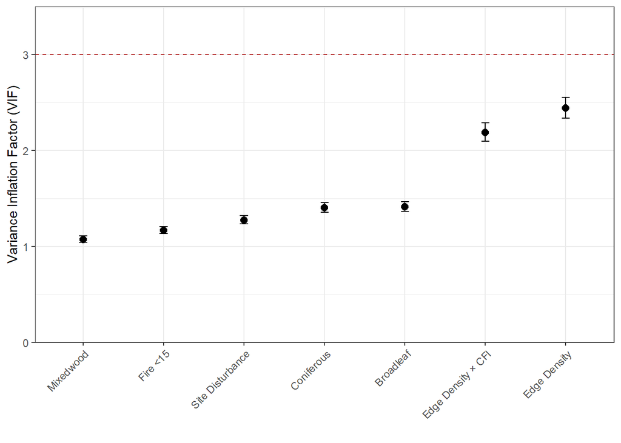

```r
# vif from the car package
performance::check_collinearity(top_model) %>%

  as.data.frame(.) %>%

  # Add the pretty names
  left_join(covs_formatted, by = c("Term" = "Covariate")) %>%

  # Manual fix for a couple of them
  mutate(PrettyName = case_when(
    Term == "nonanthro_ed:cfi_site" ~ "Edge Density × CFI",
    TRUE ~ PrettyName)) %>%

  # plot with ggplot
  ggplot(aes(x = reorder(PrettyName, VIF), # reorders from smallest VIF to largest (not sure I want like this)
             y = VIF)) +

    geom_hline(yintercept = 3, linetype='dashed', col = 'firebrick') +

    # Error bars behind the points
    geom_errorbar(aes(ymin = VIF_CI_low, ymax = VIF_CI_high), width = 0.1) +  # Error bars

    # plot as points
    geom_point(size = 2.5) +

    # add labels
    labs(x = '',
         y = 'Variance Inflation Factor (VIF)') +

    scale_y_continuous(limits = c(0, 3.2), expand = expansion(add = c(0, 0.3))) +

    # set theme
    theme_bw() +

    theme(axis.text.x = element_text(angle = 45, hjust = 1))  # Rotate x-axis labels by 45 degrees
```

```r
ggsave("./figures/top_model_neg_binomial_VIF.png", dpi=500, width = 5, height = 3.5)
```

# 7. Interpret results

## 7.1. Model summary

```r
summary(top_model)
```

```
##  Family: nbinom2  ( log )
## Formula:
## squirrel ~ fire_0_15 + lc_broadleaf + lc_coniferous + lc_mixedwood +
##     nonanthro_ed + cfi_site + nonanthro_ed * cfi_site + (1 |      array/site)
## Data: data_final_scaled
##
##      AIC      BIC   logLik deviance df.resid
##   9394.4   9465.9  -4686.2   9372.4     4907
##
## Random effects:
##
## Conditional model:
##  Groups     Name        Variance Std.Dev.
##  site:array (Intercept) 2.502    1.5816
##  array      (Intercept) 0.410    0.6403
## Number of obs: 4918, groups:  site:array, 430; array, 10
##
## Dispersion parameter for nbinom2 family (): 0.811
##
## Conditional model:
##                       Estimate Std. Error z value Pr(>|z|)
## (Intercept)           -1.42793    0.23031  -6.200 5.65e-10 ***
## fire_0_15              0.15770    0.11215   1.406   0.1597
## lc_broadleaf          -0.51842    0.12835  -4.039 5.36e-05 ***
## lc_coniferous         -0.03228    0.11093  -0.291   0.7710
## lc_mixedwood           0.16358    0.09223   1.774   0.0761 .
## nonanthro_ed          -0.08884    0.16631  -0.534   0.5932
## cfi_site               0.29548    0.12080   2.446   0.0144 *
## nonanthro_ed:cfi_site -0.25618    0.10011  -2.559   0.0105 *
## ---
## Signif. codes:  0 '***' 0.001 '**' 0.01 '*' 0.05 '.' 0.1 ' ' 1
```

## 7.2. Odds ratio plots for the conditional model:

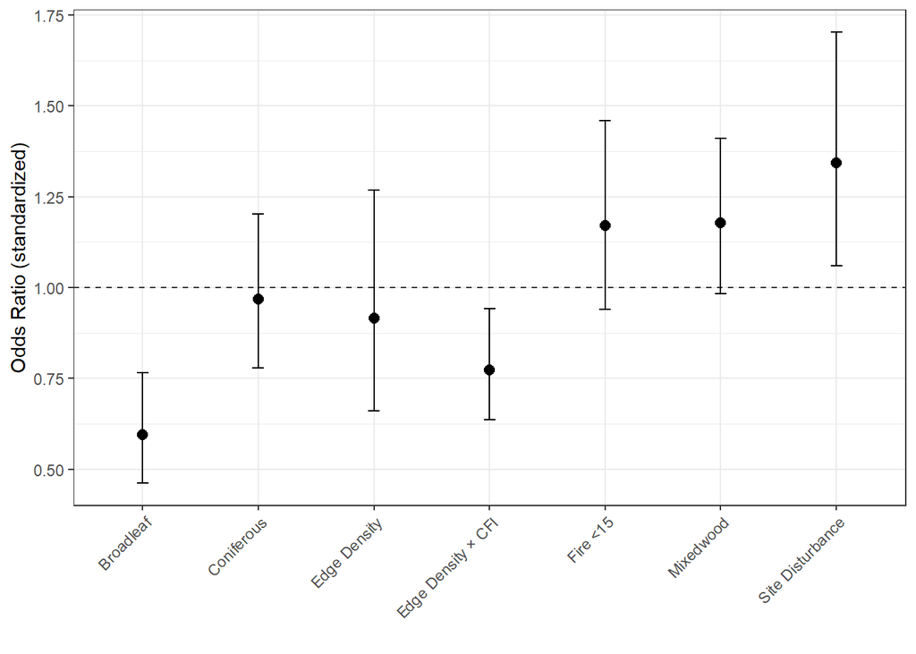

```r
confint(top_model) %>%

  as_tibble(rownames = "term") %>%

  # Rename the columns manually
  set_names(c('term', 'lower', 'upper', 'estimate')) %>%

  # Go from log odds back to odds
  mutate(across(c('lower', 'upper', 'estimate'), exp)) %>%

  # Remove things we dont wanna plot
  filter(term %nin% c('(Intercept)', 'Std.Dev.(Intercept)|array',  'Std.Dev.(Intercept)|site:array')) %>%

  # PRetty names
  left_join(covs_formatted, by = c("term" = "Covariate")) %>%

  # Fix a couple manually
  mutate(PrettyName = case_when(
    term == "nonanthro_ed:cfi_site" ~ "Edge Density × CFI",
    TRUE ~ PrettyName)) %>%

  # Plot it!!
  ggplot(., aes(x = PrettyName)) +

    geom_hline(yintercept = 1, linetype='dashed', col = 'grey20') +

    # Error bars behind the points
    geom_errorbar(aes(x = PrettyName, ymin = lower, ymax = upper), width = 0.1) +  # Error bars

    # plot as points
    geom_point(aes(y = estimate), size = 2.5) +

    # add labels
    labs(x = '',
         y = 'Odds Ratio (standardized)') +

    # set theme
    theme_bw() +

    theme(axis.text.x = element_text(angle = 45, hjust = 1)) #+   # Rotate x-axis labels by 45 degrees
```

```r
    #add_phylopic(
    #  uuid = get_uuid(name = "Sciurus vulgaris"),
    #  x = 6.6,
    #  y = 1.6,
    #  height = 0.22
    #  )

ggsave("./figures/top_model_neg_binomial_odds_ratios.png", width = 5, height = 3.5)
```

# 8. Plot conditional effects for a covariate of interest

We will use our scaling summary here to backtransform the data into ecologically meaningful values. This is a bit hacky but it works.

### Decid:

```
## You are calculating adjusted predictions on the population-level (i.e.
##   `type = "fixed"`) for a *generalized* linear mixed model.
##   This may produce biased estimates due to Jensen's inequality. Consider
##   setting `bias_correction = TRUE` to correct for this bias.
##   See also the documentation of the `bias_correction` argument.
```

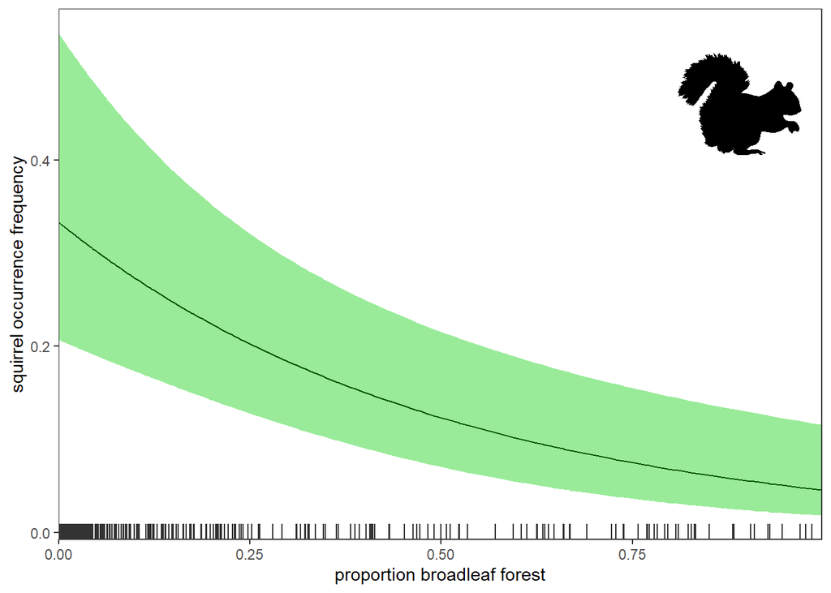

```r
# Get just the row that contains the mean and SD for backtransforming....
# Hacky I KNOW don't judge me we had 2 weeks to do this
backtransform <- data_scaled_summary %>%
  filter(buffer_dist == nat_buffer,
         variable == "lc_broadleaf")

# Use ggeffects to predict at all values of lc_broadleaf in the dataset
ggeffects::ggpredict(top_model, terms = c("lc_broadleaf [all]")) %>%

  as.data.frame() %>%

  # Apply the backtransform to the values for the x axis, predictions unchanged :)
  mutate(x = x * backtransform$sd + backtransform$mean) %>%

  ggplot(., aes(x = x, y = predicted)) +

    geom_line(size = 0.5) +  # Set lines to black

    # Confidence ribbon in front of the line
    geom_ribbon(aes(ymin = conf.low, ymax = conf.high), alpha = 0.4, fill = 'green3') +

    # Show unscaled data points for just the buffer distances that we want.
    geom_rug(data = data%>%filter(buffer_dist==nat_buffer), aes(x = lc_broadleaf), color = "grey20", inherit.aes = FALSE) +

    labs(x = "proportion broadleaf forest",
         y = "squirrel occurrence frequency") +

    scale_x_continuous(expand = c(0, 0)) +  # Remove left blank space

    theme_bw() +

    theme(panel.grid = element_blank()) +

    # Squirrel icon for fun
    add_phylopic(
      uuid = get_uuid(name = "Sciurus vulgaris"),
      x = 0.89,
      y = 0.46,
      height = 0.11
      )
```

```r
ggsave("./figures/top_model_neg_binomial_broadleaf.png", dpi=400, width = 6, height = 4)
```